# Creative Scala

Dave Gurnell and Noel Welsh

# Foreword

Creative Scala is aimed at developers who have no prior experience in Scala. It is designed to give you a fun introduction to functional programming. We assume you have some familiarity with another programming language but little or no experience with Scala or other functional languages.

Our goal is to demonstrate the building blocks that Scala developers use to create programs in a clear, succinct, declarative manner. Working through the exercises in the book should take a few hours, after which we hope you will have a feel of what Scala can do for your applications.

# 1 Expressions, Values, and Types

Scala programs have three fundamental building blocks: *expressions*, *values*, and *types*. An *expression* is a fragment of Scala code that we write in an a text editor. Valid expressions have a *type* and calculate a *value*. For example, this expression has the type `String` and calculates the value `HELLO WORLD!`

```scala
"Hello world!".toUpperCase
// res0: String = "HELLO WORLD!"
```

A Scala program goes through two distinct stages. First it is *compiled*; if compiles successfully it can then be *executed*. The most important distinction between types and values is that types are determined at compile time, whereas values can only be determined at run time. Values can change each time we run the code, whereas types are fixed. For example, the following expression is certainly of type `String`, but its value depends on the the user input each time it is run:

```scala
readLine.toUpperCase
```

We are used to thinking of types that refer to sets of literals such as `Int`, `Boolean`, and `String`, but in general a type is defined as *anything we can infer about a program without running it*. Scala developer use types to gain assurances about our programs before we put them into production.

## 1.1 Simple Scala Expressions

Let’s look at some of the basic kinds of expressions we can write in Scala:

### 1.1.1 Literals

The simplest kinds of expressions are *literals*. These are fragments of code that “stand for themselves”. Scala supports a similar set of literals to Java:

```scala
// Integers:
1
// res0: Int = 1

// Floating point numbers:
0.1
// res1: Double = 0.1

// Booleans:
true
// res2: Boolean = true

// Strings:
"Hello world!"
// res3: String = Hello world!

// And so on...
```

### 1.1.2 Method Calls

Scala is a completely object-oriented programming language, so all values are objects with methods that we can call. Method calls are another type of expression:

```scala
123.4.ceil
// res4: Double = 124.0

true.toString
// res5: String = "true"
```

### 1.1.3 Constructor Calls

Scala only has literals for a small set of types (`Int`, `Boolean`, `String`, and so on). To create values of other types we either need to call a method, or we need to call a *constructor* using the `new` keyword. This behaves similarly to `new` in Java:

```scala
import java.util.Date
// import java.util.Date

new Date()
// res4: java.util.Date = Tue Feb 10 10:30:21 GMT 2015
```

The `new` operator tends to be a distraction when writing larger, more complex expressions. For this reason, Scala libraries typically provide *factory methods* to wrap constructor calls. The effective difference is that we can create many Scala data types without writing `new`:

```scala
List(1, 2, 3)
// res6: List[Int] = List(1, 2, 3)
```

Other than the lack of a `new` keyword, the semantics here are similar to the `Date` example above:

- `List(1, 2, 3)` is an expression that returns a value;
- `List[Int]` is its type.

### 1.1.4 Operators

Operators in Scala are actually method calls under the hood. Scala has a set of convenient syntactic shorthands to allow us to write normal-looking code without excessive numbers of parentheses. The most common of these is *infix syntax*, which allows us to write any expression of the form `a.b(c)` as `a b c`, without the full stop or parentheses:

```scala
1 .+(2).+(3).+(4) // the space prevents `1` being treated as a double
// res0: Int = 10

1 + 2 + 3 + 4
// res1: Int = 10
```

### 1.1.5 Conditionals

Many other syntactic constructs are expressions in Scala, including some that are statements in Java. Conditionals (“if expressions”) are a great example:

```scala
// Conditionals ("if expressions"):
if(123 > 456) "Higher!" else "Lower!"
// res6: String = Lower!
```

### 1.1.6 Blocks and Side-Effects

Blocks are another type of expression in Scala. Running a block runs each contained expression in order. The type and return value of the block are determined by the *last* contained expression:

```scala
{
  println("First line")
  println("Second line")
  1 + 2 + 3
}
// res0: Int = 6
```

In functional programming we make the distiction between “pure expressions” and expressions that have “side effects”:

- *pure expressions* do nothing more than calculate a value;
- expressions with *side effects* do something else aside from calculate their result—for example, `println` prints a message to the console.

Because the results of intermediate expressions in a block are thrown away, it doesn’t make sense to use pure expressions there. The Scala console even warns us when we try this:

```scala
{
  1 + 2 + 3
  4 + 5 + 6
}
// <console>:9: warning: a pure expression does nothing in statement position;
//              you may be omitting necessary parentheses
//                1 + 2 + 3
//                      ^
// res0: Int = 15
```

The message here is warning us that the intermediate expression `1 + 2 + 3` is wasted computation. All it does is calculate the value `6`. We immediately throw the result away and calculate `4 + 5 + 6` instead. We might as well simply write `4 + 5 + 6` and get rid of the block.

Side-effecting expressions, by contrast, make perfect sense within a block. `println` expressions are a great example of this—they do something useful even though they don’t return a useful value:

```scala
{
  println("Intermediate result: " + (1 + 2 + 3))
  4 + 5 + 6
}
// Intermediate result: 6
// res0: Int = 15
```

Scala developers tend to prefer pure expressions to side-effects because they are easier to reason about. See the section on Substitution for more information. We won’t use blocks in anger until the next chapter when we start declaring intermediate values and re-use them in later expressions.

## 1.2 Images

Numbers and text are boring. Let’s switch to something more interesting—images! Grab the *Doodle* project from https://github.com/underscoreio/doodle. This toy drawing library will provide the basis for most of the exercises in this course. Start a Scala console to try Doodle out:

```bash
bash$ git clone https://github.com/underscoreio/doodle.git
# Cloning ...

bash$ cd doodle

bash$ ./sbt.sh console
[info] Loading project definition from /.../doodle/project
[info] Set current project to doodle (in build file:/.../doodle/)
[info] Compiling 1 Scala source to /.../doodle/jvm/target/scala-2.11/classes...
[info] Starting scala interpreter...
[info]
import doodle.core._
import doodle.syntax._
import doodle.jvm.Java2DCanvas._
import doodle.backend.StandardInterpreter._
import doodle.examples._
Welcome to Scala version 2.11.7 (Java HotSpot(TM) 64-Bit Server VM, Java 1.8.0_20-ea).
Type in expressions to have them evaluated.
Type :help for more information.

scala>
```

### 1.2.1 Primitive Images

The Doodle console gives us access to some useful drawing tools as well as the regular Scala standard library. Try creating a simple shape:

```scala
Circle(10)
// res0: doodle.core.Circle = Circle(10.0)
```

*How To Run This Example*

When you see an example like the one above, enter the line of Scala code at the `scala>` prompt in the console. You should see the text in the comment as output:

```scala
scala> Circle(10)
res0: doodle.core.Circle = Circle(10.0)
```

We haven’t written the `scala>` prompts in the examples in this book because they make it difficult to copy and paste text into the console. We’ve written the console output as comments for the same reason.

Notice the type and value of the expression we just entered. The type is `doodle.core.Circle` and the value is `Circle(10.0)`—a circle with a 10 pixel radius.

We can draw this circle (and other images) using the `draw` method. Try drawing the circle now:

```scala
res0.draw
```

A window should appear containing the following:

[figure not shown]

A circle

Doodle supports a handful “primitive” images: circles, rectangles, and triangles. Let’s try drawing a rectangle:

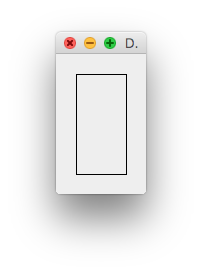

A rectangle

```scala
Rectangle(50, 100).draw
```

Finally let’s try a triangle:

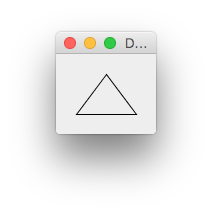

A triangle

```scala
Triangle(60, 40).draw
```

### 1.2.2 Layout

We can write expressions to combine images producing more complex images. Try the following code—you should see a circle and a rectangle displayed beside one another:

[figure not shown]

A circle beside a rectangle

```scala
(Circle(10) beside Rectangle(10, 20)).draw
```

Doodle contains several layout operators for combining images. Try them out now to see what they do:

| Operator | Type | Description | Example |
| --- | --- | --- | --- |
| `Image beside Image` | `Image` | Places images horizontally next to one another. | `Circle(10) beside Circle(20)` |
| `Image above Image` | `Image` | Places images vertically next to one another. | `Circle(10) above Circle(20)` |
| `Image below Image` | `Image` | Places images vertically next to one another. | `Circle(10) below Circle(20)` |
| `Image on Image` | `Image` | Places images centered on top of one another. | `Circle(10) on Circle(20)` |
| `Image under Image` | `Image` | Places images centered on top of one another. | `Circle(10) under Circle(20)` |

**Exercise: Compilation Target**

Create a line drawing of an archery target with three concentric scoring bands:

[figure not shown]

Simple archery target

For bonus credit add a stand so we can place the target on a range:

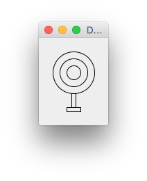

Archery target with a stand

The simplest solution is to create three concentric circles using the `on` operator:

```scala
(Circle(10) on Circle(20) on Circle(30)).draw
```

For the extra credit we can create a stand using two rectangles:

```scala
(
  Circle(10) on
  Circle(20) on
  Circle(30) above
  Rectangle(6, 20) above
  Rectangle(20, 6)
).draw
```

### 1.2.3 Colour

In addition to layout, Doodle has some simple operators to add a splash of colour to our images. Try these out to see how they work:

| Operator | Type | Description | Example |
| --- | --- | --- | --- |
| `Image fillColor Color` | `Image` | Fills the image with the specified colour. | `Circle(10) fillColor Color.red` |
| `Image lineColor Color` | `Image` | Outlines the image with the specified colour. | `Circle(10) lineColor Color.blue` |
| `Image lineWidth Int` | `Image` | Outlines the image with the specified stroke width. | `Circle(10) lineWidth 3` |

Doodle has various ways of creating colours. The simplest are the predefined colours in `shared/src/main/scala/doodle/core/CommonColors.scala`. Here are a few of the most important:

| Color | Type | Example |
| --- | --- | --- |
| `Color.red` | `Color` | `Circle(10) fillColor Color.red` |
| `Color.blue` | `Color` | `Circle(10) fillColor Color.blue` |
| `Color.green` | `Color` | `Circle(10) fillColor Color.green` |
| `Color.black` | `Color` | `Circle(10) fillColor Color.black` |
| `Color.white` | `Color` | `Circle(10) fillColor Color.white` |
| `Color.gray` | `Color` | `Circle(10) fillColor Color.gray` |
| `Color.brown` | `Color` | `Circle(10) fillColor Color.brown` |

**Exercise: Stay on Target**

Colour your target red and white, the stand in brown (if applicable), and some ground in green:

[figure not shown]

Colour archery target

The trick here is using parentheses to control the order of composition. The `fillColor()`, `lineColor()`, and `lineWidth()` methods apply to a single image—we need to make sure that image comprises the correct set of shapes:

```scala
(
  ( Circle(10) fillColor Color.red ) on
  ( Circle(20) fillColor Color.white ) on
  ( Circle(30) fillColor Color.red lineWidth 2 ) above
  ( Rectangle(6, 20) above Rectangle(20, 6) fillColor Color.brown ) above
  ( Rectangle(80, 25) lineWidth 0 fillColor Color.green )
).draw
```

## 1.3 Take Home Points

### 1.3.1 Substitution

In the absence of side-effects, an expression will always evaluate to the same value. For example, `3 + 4` will always evaluate to `7` no matter how many times we compile or run the code.

Given these restrictions, the expressions `3 + 4` and `7` become interchangeable from a user’s point of view. This is known as the *substitution model* of evaluation, although you may remember it as “simplifying formulae” from your maths class at school.

As programmers we must develop a mental model of how our code operates. In the absence of side-effects, the substution model always works. If we know the types and values of each component of an expression, we know the type and value of the expression as a whole.

Functional programmers aim to avoid side-effects for this reason: it makes our programs easy to reason about without having to look beyond the current block of code.

### 1.3.2 Types in Scala

We’ve seen several types so far, including primitive Scala types such as `Int`, `Boolean`, and `String`, the `Date` type from the Java standard library, `List` from the Scala standard library, and the `Circle`, `Rectangle`, `Image`, and `Color` types from Doodle. Let’s take a moment to see how all of these fit together:

[figure not shown]

Scala’s type hierarchy

All types in Scala fall into a single *inheritance hierarchy*, with a grand supertype called `Any` at the top. `Any` has two subtypes, `AnyVal` and `AnyRef`.

- `AnyVal` is a supertype of the JVM’s fixed set of “value types”, all of which which we know from Java: `Int` is `int`, `Boolean` is `boolean`, and so on. `AnyVal` is also the supertype of `Unit`, which we will discuss in a moment.
- `AnyRef` is the supertype of all JVM “reference types”. It is an alias for Java’s `Object` type. `AnyRef` is the supertype of all Java and Scala classes.

The `Unit` type is Scala’s equivalent of `void` in Java or C—we use it to write code that evaluates to “no interesting value”:

```scala
val uninteresting = println("Hello world!")
// Hello world!
// uninteresting: Unit = ()
```

While `void` is simply a syntax, `Unit` is an actual type with a single value, `()`. Having an concrete type for `Unit` and value allows us to reason about side-effecting code with the same principles as functional code. This is essential for a language like Scala that bridges the worlds of the imperative and the functional.

We have so far seen two imperative-style methods that return `Unit`: the `println` method from the Scala standard library and Doodle’s `draw` method. Each of these methods does something useful but neither returns a useful result:

```scala
val alsoUninteresting = Circle(10).draw
// alsoUninteresting: Unit = ()
```

Designing programs in a functional way involves limiting the side-effects spread throughout our code. Doodle is a classic example of functional design—we assemble a *representation* of the scene we want in a purely functional manner, and then *interpret* the scene to produce output. The `draw` method—our interpreter—can use imperative libraries and mutable state without them intruding into the rest of our application.

# 2 Declarations

Not all programs are single expressions. Sometimes it is useful to bind expressions to a name and re-use them later. These constructs are called *declarations*. Declarations themselves don’t have a type or a value. However, they do bind names that can be used as expressions. There are several types of declaration in Scala as we shall see below.

## 2.1 Value Declarations

The simplest type of declaration binds a name to the result an expression. These are called *value declarations*. They are similar to *variable declarations*, except we cannot assign new values to them after declaration:

```scala
val blackSquare = Rectangle(30, 30) fillColor Color.black
// blackSquare: doodle.Image = // ...

val redSquare = Rectangle(30, 30) fillColor Color.red
// redSquare: doodle.Image = // ...
```

**Exercise: Chess Board**

Create an 8x8 square chess board without loops or comprehensions, using the definitions of `redSquare` and `blackSquare` above. Use intermediate value declarations to make your code as compact as possible:

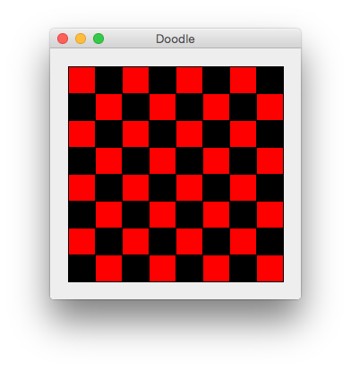

Chess board

An 8x8 chess board can be decomposed into four 4x4 boards, each consisting four 2x2 boards, each consisting four squares:

```scala
val blackSquare = Rectangle(30, 30) fillColor Color.black
val redSquare   = Rectangle(30, 30) fillColor Color.red

val twoByTwo =
  (redSquare   beside blackSquare) above
  (blackSquare beside redSquare)

val fourByFour =
  (twoByTwo beside twoByTwo) above
  (twoByTwo beside twoByTwo)

val chessBoard =
  (fourByFour beside fourByFour) above
  (fourByFour beside fourByFour)
```

This is significantly clearer and more compact than creating the whole board in one expression:

```scala
val b = Rectangle(30, 30) fillColor Color.black
val r = Rectangle(30, 30) fillColor Color.red

val chessBoard =
  (r beside b beside r beside b beside r beside b beside r beside b) above
  (r beside b beside r beside b beside r beside b beside r beside b) above
  (r beside b beside r beside b beside r beside b beside r beside b) above
  (r beside b beside r beside b beside r beside b beside r beside b) above
  (r beside b beside r beside b beside r beside b beside r beside b) above
  (r beside b beside r beside b beside r beside b beside r beside b) above
  (r beside b beside r beside b beside r beside b beside r beside b) above
  (r beside b beside r beside b beside r beside b beside r beside b)
```

## 2.2 Method Declarations

Sometimes we want to repeat a process, but each time we do it we change some part of what we’re doing. For example, imagine creating chess boards where each chess board has a different combination of colors. It would be extremely tedious to declare each chess board as we have above for each choice of colors. What we’d like is to be able to define some process for making chess boards that allows the user to specify the color choice for the particular chess board we’re making. This is what *methods* allow us to do.

We have already seen method calls. In this section we are going to see how we can declare our own methods. Like value declarations, method declarations define a name. Instead of giving a name to a value, a method declaration gives a name to a process for creating values:

```scala
def twoByTwo(color1: Color, color2: Color): Image = {
  val square1 = Rectangle(30, 30) fillColor color1
  val square2 = Rectangle(30, 30) fillColor color2

  (square1 beside square2) above
  (square2 beside square1)
}
```

This declares a method called `twoByTwo`. The method has two parameters, called `color1` and `color2`, which we have declared to have type `Color`. We have also declared the type of the value returned—`Image`. The body of the method, which is enclosed with optional braces (the `{` and `}` pair) defines how we create the `Image`. This mirrors the process for creating a two by two chess board that we saw above, but in this case we are using the colors we are passed as parameters.

**Exercise: Chess Board**

Declare a method called `fourByFour` that constructs a four-by-four chess board using `twoByTwo` declared above. The method should have two parameters, both `Color`s, that it passes on to `twoByTwo`.

You should be able to call `fourByFour` like so

```scala
fourByFour(Color.cornflowerBlue, Color.seaGreen) beside
fourByFour(Color.chocolate, Color.darkSalmon)
```

to create this picture:

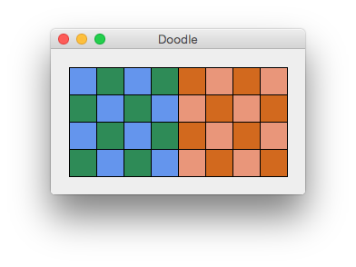

Two Chessboards

The structure of `fourByFour` is identical to `twoByTwo` except that we use `twoByTwo` to construct the squares we build the board.

```scala
def fourByFour(color1: Color, color2: Color): Image = {
  val square = twoByTwo(color1, color2)

  (square beside square) above
  (square beside square)
}
```

*Syntax Summary*

We’ve seen quite a lot of Scala syntax so far. If you can’t remember everything we’ve covered, don’t panic! There’s a syntax quick reference in the appendices at the end of the book.

## 2.3 Extended Exercise: Color Palettes

In this exercise we will explore the creation of color palettes. An attractive picture must make good choices for color. Color theory has developed to explain combinations of color that go together. We will use color theory to create programs that can automatically construct attractive color palettes.

### 2.3.1 Color Representation

In Doodle we can represent a color in one of two ways:

1. as triples containing red, green, and blue values (RGB); or
2. as hue, saturation, and lightness (HSL).

We will use the HSL representation as it better corresponds to our perception of color. If we arrange colors in the familiar color wheel, distance from the center corresponds to lightness and steps around the outside correspond to changes in hue:

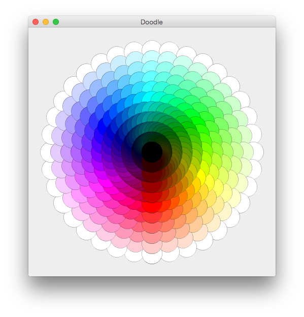

A color wheel. A full turn around the wheel represents a 360 degree change in hue.

Saturation, the third dimension, corresponds to intensity of color. The strip of colors below shows the effect of varying saturation from 0.0 to 1.0, for fixed hue (170 degrees) and lightness (0.5). As you can see, changing saturation goes from a dull gray to a bright and vibrant color.

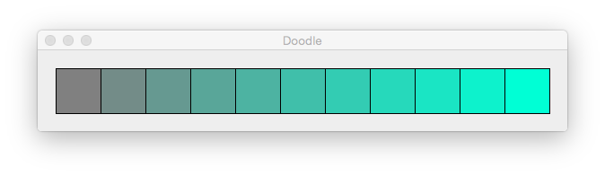

The effect of changing saturation while keeping hue and lightness fixed. Saturation increases from left to right, starting at zero and finishing at one.

### 2.3.2 The Color API

Before we can create color schemes we need to know how to create and manipulate colors.

#### 2.3.2.1 Creating Colors

There are two main methods to create colours:

```scala
Color.hsl(hue: Angle, saturation: Normalized, lightness: Normalized)
Color.rgb(red: UnsignedByte, green: UnsignedByte, blue: UnsignedByte)
```

These methods use types — `Angle`, `Normalized`, and `UnsignedByte` — that have not seen before. They all represent numbers with some special characteristics. A `Normalized` is a number between 0 and 1. An `UnsignedByte` is an integer between 0 and 255. An `Angle` is unrestricted in value but there are several operations that only make sense on angles (sine, cosine, and so on) and several representations (angles, radians) in common use.

The `Normalized` and `UnsignedByte` types make it explicit that some conversion is necessary from raw number types like `Int` and `Double`. There are many different ways to handle inputs that are out of range, such as clipping them or raising an error, and we require the programmer to be explicit about the approach they want.

For `Normalized` and `UnsignedByte` Doodle provides a default conversion of clipping. For example, if we are creating a `Normalized` (value between 0.0 and 1.0), any input less than 0.0 is set to 0.0 and greater than 1.0 becomes 1.0. To use these conversions import `doodle.syntax.normalized._` or `doodle.syntax.uByte._` and then numbers are *enriched* with methods `normalized` and `uByte` respectively. Here’s a quick example. Notice how values out of range are set to the closest valid value.

```scala
import doodle.syntax.normalized._

0.5.normalized
//res: doodle.core.Normalized = Normalized(0.5)
0.0.normalized
//res: doodle.core.Normalized = Normalized(0.0)
-0.5.normalized
//res: doodle.core.Normalized = Normalized(0.0)
1.5.normalized
//res: doodle.core.Normalized = Normalized(1.0)

import doodle.syntax.uByte._

128.uByte
//res: doodle.core.UnsignedByte = UnsignedByte(0)
0.uByte
//res: doodle.core.UnsignedByte = UnsignedByte(-128)
255.uByte
//res: doodle.core.UnsignedByte = UnsignedByte(127)
-127.uByte
//res: doodle.core.UnsignedByte = UnsignedByte(-128)
512.uByte
//res: doodle.core.UnsignedByte = UnsignedByte(127)
```

For `Angle` we ask the programmer to specify if the raw number represents a value in degrees, radians, or turns (fractions of a circle, with a full circle being one turn). For `Angles` the import is `doodle.syntax.angle._` which enriches numbers with methods `degrees`, `radians`, and `turns`. Here’s an example:

```scala
import doodle.syntax.angle._

0.degrees
//res: doodle.core.Angle = Angle(0.0)
180.degrees
//res: doodle.core.Angle = Angle(3.141592653589793)
360.degrees
//res: doodle.core.Angle = Angle(6.283185307179586)

math.Pi
//res: Double = 3.141592653589793
math.Pi.radians
//res: doodle.core.Angle = Angle(3.141592653589793)

0.5.turns
//res: doodle.core.Angle = Angle(3.141592653589793)
1.0.turns
//res: doodle.core.Angle = Angle(6.283185307179586)
```

We can now create some colors:

```scala
Color.hsl(170.degrees, 1.0.normalized, 0.5.normalized)
// res: doodle.core.HSLA = HSLA(Angle(2.9670597283903604),Normalized(1.0),Normalized(0.5),Normalized(1.0))
```

Note that the color we created has four fields. The fourth field is the `alpha` value, which specifies the opacity of the color. There are four parameter methods `Color.hsla` and `Color.rgba` that can be used to specify the `alpha` when creating a color.

#### 2.3.2.2 Modifying Colors

There are several methods to modify colors. These methods all create a new `Color`. No `Color` is ever actually changed after it is created, as doing so breaks substitution.

New `hue`, `saturation`, `lightness`, and `alpha` values can all be set with methods of the same name. Notice how the original color is unchanged.

```scala
val c = Color.hsl(170.degrees, 1.0.normalized, 0.5.normalized)
//c: doodle.core.HSLA = HSLA(Angle(2.9670597283903604),Normalized(1.0),Normalized(0.5),Normalized(1.0))

c.hue(220.degrees)
//res: doodle.core.Color = HSLA(Angle(3.839724354387525),Normalized(1.0),Normalized(0.5),Normalized(1.0))

c.saturation(0.5.normalized)
//res: doodle.core.Color = HSLA(Angle(2.9670597283903604),Normalized(0.5),Normalized(0.5),Normalized(1.0))

c.lightness(0.25.normalized)
//res: doodle.core.Color = HSLA(Angle(2.9670597283903604),Normalized(1.0),Normalized(0.25),Normalized(1.0))

c.alpha(0.5.normalized)
//res: doodle.core.Color = HSLA(Angle(2.9670597283903604),Normalized(1.0),Normalized(0.5),Normalized(0.5))

c
//res: doodle.core.HSLA = HSLA(Angle(2.9670597283903604),Normalized(1.0),Normalized(0.5),Normalized(1.0))
```

There are also methods to adjust the existing `hue`, `saturation`, `lightness`, and `alpha`. These methods all create a new color by adding or subtracting from the existing value of the parameter of interest.

```scala
val c = Color.hsl(170.degrees, 1.0.normalized, 0.5.normalized)
//c: doodle.core.HSLA = HSLA(Angle(2.9670597283903604),Normalized(1.0),Normalized(0.5),Normalized(1.0))

c.spin(220.degrees)
//res: doodle.core.HSLA = HSLA(Angle(6.806784082777885),Normalized(1.0),Normalized(0.5),Normalized(1.0))

c.lighten(0.2.normalized)
//res: doodle.core.HSLA = HSLA(Angle(2.9670597283903604),Normalized(1.0),Normalized(0.7),Normalized(1.0))

c.darken(0.2.normalized)
//res: doodle.core.HSLA = HSLA(Angle(2.9670597283903604),Normalized(1.0),Normalized(0.3),Normalized(1.0))

c.saturate(0.2.normalized)
//res: doodle.core.HSLA = HSLA(Angle(2.9670597283903604),Normalized(1.0),Normalized(0.5),Normalized(1.0))

c.desaturate(0.2.normalized)
//res: doodle.core.HSLA = HSLA(Angle(2.9670597283903604),Normalized(0.8),Normalized(0.5),Normalized(1.0))

c.fadeIn(0.2.normalized)
//res: doodle.core.HSLA = HSLA(Angle(2.9670597283903604),Normalized(1.0),Normalized(0.5),Normalized(1.0))

c.fadeOut(0.2.normalized)
//res: doodle.core.HSLA = HSLA(Angle(2.9670597283903604),Normalized(1.0),Normalized(0.5),Normalized(0.8))
```

### 2.3.3 Complementary Colors

A simple way to generate colors that look good together is to use *complementary colors*. Given a color, it’s complement is the one opposite it on the color wheel. In other words, it has hue rotated by 180 degrees. Complementary pairs have high contrast and make for striking compositions:

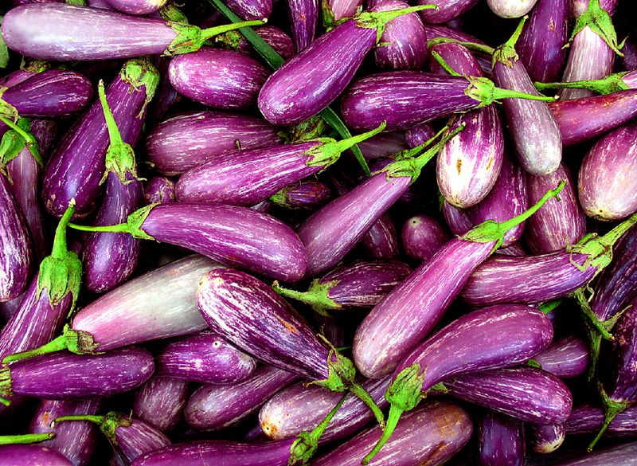

Aubergines by [Estaban Cavrico](https://www.flickr.com/photos/36179943@N00/219265991) [CC BY-NC-ND 2.0](https://creativecommons.org/licenses/by-nc-nd/2.0/). The green and purple of the aubergins are near complements.

**Exercise: Complementary Colors**

Create a method `complement` that takes a `Color` as input and returns its complement. You can use the method `spin` on a `Color` to rotate its hue by a given `Angle`.

```scala
def complement(color: Color): Color =
  color.spin(180.degrees)
```

**Exercise: Complementary Chess Boards**

Using `complement` write a method `complementaryChessBoard` that creates a four-by-four chess board using a complementary color scheme. This method should take a `Color` input. Here’s the method signature:

```scala
def complementaryChessBoard(color: Color): Image = ???
```

You should end up with a picture like the below.

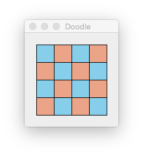

A chess board colored using complementary colors

We can build the method using the methods we have already created.

```scala
def complementaryChessBoard(color: Color) =
  fourByFour(color, complement(color))
```

### 2.3.4 Analogous Colors

Complementary colors can be quite harsh on the eyes. We can play around with saturation and lightness to decrease the contrast but ultimately this color scheme is quite limited. Let’s explore another color scheme, *analogous colors*, that gives us more flexibility.

In analogous color is simply one that is close on the color wheel to a given color. We can generate an analogous color by spinning hue, say, fifteen degrees.

**Exercise: Analogous Colors**

Create a method `analogous` that takes a `Color` as input and returns an analogous color.

```scala
def analogous(color: Color): Color =
  color.spin(15.degrees)
```

**Exercise: Analogous Chess Boards**

Now create a method `analogousChessBoard` that creates a four-by-four chess board with an analogous color scheme. You should get a result like the below.

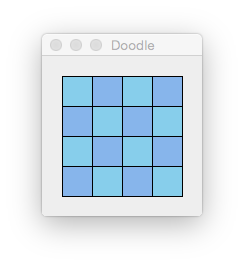

A chess board colored using analogous colors

This follows the same pattern as `complementaryChessBoard`. Notice how we build big things (a colored chess board) out of smaller component parts. This idea of composing small pieces of code into larger pieces is one of the key ideas in functional programming.

```scala
def analogousChessBoard(color: Color) =
  fourByFour(color, analogous(color))
```

### 2.3.5 Beyond Two-Color Palettes

We have seen how we can build very simple color palettes from complementary and analogous colors. Now let’s combine these ideas to build more complex palettes. A *tetrad color scheme* consists of two analogous colors and their complements.

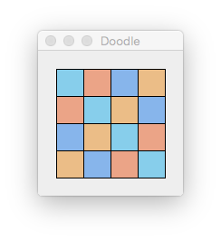

A chess board colored using a tetradic color scheme

Define a method `tetradChessBoard` that creates a chess board colored with a tetradic color scheme as illustrated. Use the following skeleton

```scala
def tetradChessBoard(color: Color) = ???
```

Hint: You will have to call `twoByTwo`, not `fourByFour`, within the body of `tetradChessBoard`.

It would be nice to have a method for creating an entire tetradic color scheme from a single color, but we don’t currently have a way of wrapping up a collection of data so that we could return all four values from the methods. We’ll see ways of doing this later, when we introduce classes and collections.

```scala
def tetradChessBoard(color: Color) = {
  val color1 = color
  val color2 = analogous(color)
  val color3 = complement(color)
  val color4 = complement(color2)

  val square1 = twoByTwo(color1, color3)
  val square2 = twoByTwo(color2, color4)

  (square1 beside square2) above
  (square2 beside square1)
}
```

## 2.4 Take Home Points

Some programs cannot be written in a single expression!

Scala provides *value declarations* as a means to capture and re-use values in the rest of our code. Because Doodle is based on immutable data structures, we can re-use single values multiple times without worrying about unintended side-effects. The chessboard example demonstrates this nicely—it re-uses the `fourByFour` value four times and the `twoByTwo` value sixteen times, resulting in a compact memory-efficient representation.

Method declarations do a different job. They allow us to *abstract over parameters*, creating blocks of code that work with a variety of inputs. Functional programming places emphasis on writing methods that *return useful values*, effectively turning methods into high-level constructors.

For example, we can view a method like `tetradChessBoard()` as a constructor for a chess board. Even though the method creates many objects internally, the substitution model allows us to ignore the implementation details and treat the method as a black box.

# 3 (Functional) Programming

So far we have seen how to write literals, expressions, value declarations, and method declarations. We now have the tools to write non-trivial programs that generate complex images. In this chapter we will introduce some more tools to our functional programming toolbox and create even more complex images: recursion, first-class functions, and higher-order functions.

## 3.1 Recursive Algorithms

Recursion is a natural part of functional programming. The classic functional data structure—the single linked list—is recursive in nature. We can similarly create interesting drawings using recursion.

Let’s start with a simple example—a set of concentric circles. We can create this image by recursing over the natural numbers. Each number corresponds to the next layer of the image:

[figure not shown]

Concentric circles (n = 1 to 3)

Note the recursive pattern here:

- the `n = 1` case is the *base case*;
- every other case is the `n - 1` case (shown in black) surrounded by an extra circle (shown in red).

Given these two rules, we can generate a picture for any value of `n >= 1`. We can even model the rules directly in Scala:

```scala
def concentricCircles(n: Int): Image =
  if(n == 1) {
    // Return a circle
  } else {
    // Return a circle superimposed on the image from n - 1
  }
```

**Exercise: Concentric circles**

Create an image containing 20 concentric circles using the approach described above:

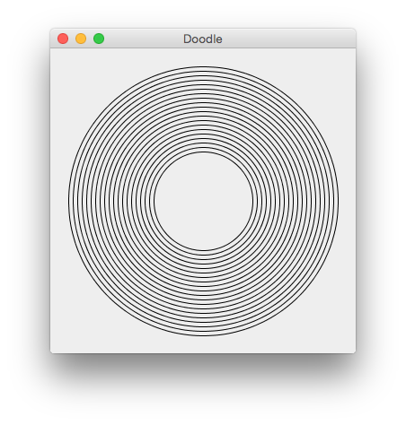

Concentric circles (n = 20)

For extra credit, give each circle its own hue or opacity by gradually changing the colour at each level of recursion:

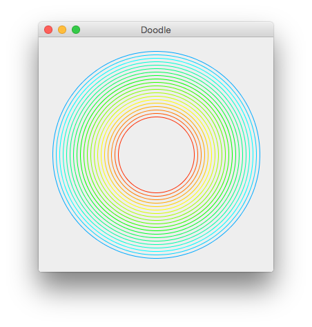

Concentric circles IN COLOUR! (n = 20)

The basic structure of our solution involves two methods: one for drawing a single circle and one for drawing `n` circles:

```scala
def singleCircle(n: Int): Image =
  ???

def concentricCircles(n: Int): Image =
  if(n == 1) {
    singleCircle(n)
  } else {
    singleCircle(n) on concentricCircles(n - 1)
  }

concentricCircles(20)
```

There is a clean division of labour here: `concentricCircles` handles the recursion through values of `n` and the composition of the shapes at each level, while `singleCircle` decides which actual shapes we draw at each level.

Here is the implementation of `singleCircle` we need to draw monochrome circles. We calculate an appropriate radius from the value of `n` provided. The `n = 1` circle has radius `55` and each successive circle is `5` pixels larger:

```scala
def singleCircle(n: Int): Image =
  Circle(50 + 5 * n)
```

To create multicolour circles, all we need to do is modify `singleCircle`. Here is an implementation for the extra credit example above:

```scala
def singleCircle(n: Int): Image =
  Circle(50 + 5 * n) lineColor (Color.red spin (n * 10).degrees)
```

Here is another implementation that fades out the further we get from `n = 1`:

```scala
def singleCircle(n: Int): Image =
  Circle(50 + 5 * n) fadeOut (n / 20).normalized
```

We can make countless different images by tweaking `singleCircle` without changing the definition of `concentricCircles`. In fact, `concentricCircles` doesn’t care about circles at all! A more general naming system would be more suitable:

```
def singleShape(n: Int): Image =
  ???

def manyShapes(n: Int): Image =
  if(n == 1) singleShape(n) else (singleShape(n) on manyShapes(n - 1))
```

**Exercise: Sierpinski triangle**

Sierpinski triangles are a more interesting example of a recursive drawing algorithm. The pattern is illustrated below:

[figure not shown]

Sierpinski triangles (n = 1 to 4)

Here is an English description of the recursive pattern:

- The base case for `n = 1` is an equilateral triangle. We can draw this in Doodle as follows:

  ```scala
  Triangle(10, 10)
  ```

- Every other case involves three copies of the `n - 1` case arranged in a triangle.

Use this description to write Scala code to draw a Sierpinski triangle. Start by dealing with the `n = 1` case, then solve the `n = 2` case, then generalise your code for any value of `n`. Finish by drawing the `n = 10` *Sier**pink**ski* triangle below:

[figure not shown]

Sierpinski triangle (n = 10)

You may notice that the final result is extremely large! For extra credit, rewrite your code so you can specify the size of the triangle up front:

```scala
def sierpinski(n: Int, size: Double): Image = ???
```

Finally, for double extra credit, answer the following questions:

1. How many pink triangles are there in your drawing?
2. How many `Triangle` objects is your code creating?
3. Is this the answer to question 2 necessarily the same as the answer to question 1?
4. If not, what is the minimum number of `Triangles` needed to draw the `n = 10` Sierpinski?

The simple solution looks like the following:

```scala
def triangle: Image =
  Triangle(1, 1) lineColor Color.magenta

def sierpinski(n: Int): Image =
  if(n == 1) {
    triangle
  } else {
    val smaller = sierpinski(n - 1)
    smaller above (smaller beside smaller)
  }

sierpinski(10)
```

The extra credit solution involves specifying the desired size up front and dividing it by two each time we recurse:

```scala
def triangle(size: Double): Image =
  Triangle(size, size) lineColor Color.magenta

def sierpinski(n: Int, size: Double): Image =
  if(n == 1) {
    triangle(size)
  } else {
    val smaller = sierpinski(n - 1, size / 2)
    smaller above (smaller beside smaller)
  }

sierpinski(10, 512)
```

Finally let’s look at the questions:

First, let’s consider the number of pink triangles. There is one triangle in the `n = 1` base Sierpinski, and we multiply this by 3 for each successive level of recursion. There are `3^9 = 19,683` triangles in the `n = 10` Sierpinski!

That’s a lot of triangles! Now let’s consider the number of `Triangle` objects. This question is designed to highlight a nice property of immutable data structures called *structural sharing*. Each Sierpinski from `n = 2` upwards is created from three smaller Sierpinskis, but they *don’t have to be different objects in memory*. We can re-use a single smaller Sierpinski three times to save on computation time and memory use.

The code above actually shows the optimal case. We use a temporary variable, `smaller`, to ensure we only call `sierpinski(n - 1)` once at each level of recursion. This means we only call `triangle()` once, no matter what value of `n` we start with.

We only need to create one `Triangle` object for the whole picture! Of course, the `draw` method has to process this single triangle 19,683 times to draw the picture, but the representation we build to begin with is extremely efficient.

## 3.2 Functions as Values

```scala
(a: Double, b: Double) => math.sqrt(a*a + b*b)
// res0: (Double, Double) => Double = <function2>

res0(3, 4)
// res1: Double = 5.0
```

Because Scala is an object oriented language, all first class values are objects. This means functions are objects, not methods! In fact, functions themselves have useful methods for composition:

```scala
(a: Int) => a + 10
// res0: Int => Int = <function1>

(a: Int) => a * 2
// res1: Int => Int = <function1>

res0 andThen res1 // this composes the two functions
// res2: Int => Int = <function1>

res2(5)
// res3: Int = 30
```

It may seem surprising and restrictive that Scala methods are not values. We can prove this by attempting to refer to a method without invoking it:

```scala
Color.rgb
// <console>:20: error: missing arguments for method rgb in object Color;
// follow this method with `_' if you want to treat it as a partially applied function
//               Color.rgb
//                     ^
```

Fortunately, as the error message above suggests, we can convert any method to a function using the `_` operator and call it with the same parameters:

```scala
Color.rgb _
// res4: (Int, Int, Int) => doodle.core.Color = <function3>

res4(255, 0, 0)
// res5: doodle.core.Color = ...
```

## 3.3 Higher Order Methods and Functions

Why are functions useful? We can already use methods to package up and name reusable fragments of code. What other advantages do we get from treating code as values?

- we can pass functions as parameters to other functions and methods;
- we can create methods that return functions as their results.

Let’s consider the pattern from the concentric circles exercise as an example:

```scala
def manyShapes(n: Int): Image =
  if(n == 1) {
    singleShape
  } else {
    singleShape on manyShapes(n - 1)
  }

def singleShape: Image = ???
```

This pattern allows us to create many different images by changing the definition of `singleShape`. However, each time we provide a new definition of `singleShape`, we also need a new definition of `manyShapes` to go with it.

We can make `manyShapes` completely general by supplying `singleShape` as a parameter:

```scala
def manyShapes(n: Int, singleShape: Int => Image): Image =
  if(n == 1) {
    singleShape(n)
  } else {
    singleShape(n) on manyShapes(n - 1, singleShape)
  }
```

Now we can re-use the same definition of `manyShapes` to produce plain circles, circles of different hue, circles with different opacity, and so on. All we have to do is pass in a suitable definition of `singleShape`:

```scala
// Passing a function literal directly:

val blackCircles: Image =
  manyShapes(10, (n: Int) => Circle(50 + 5*n))

// Converting a method to a function:

def redCircle(n: Int): Image =
  Circle(50 + 5*n) lineColor Color.red

val redCircles: Image =
  manyShapes(10, redCircle _)
```

*Function Syntax*

We’re introducing a lot of syntax here! There’s a dedicated section on function syntax in the quick reference if you get lost!

**Exercise: The Colour and the Shape**

Starting with the code below, write color and shape functions to produce the following image:

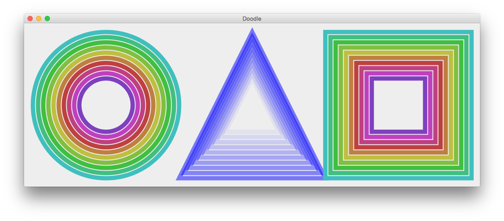

Colours and Shapes

```scala
def manyShapes(n: Int, singleShape: Int => Image): Image =
  if(n == 1) {
    singleShape(n)
  } else {
    singleShape(n) on manyShapes(n - 1, singleShape)
  }
```

The `manyShapes` method is equivalent to the `concentricCircles` method from previous exercises. The main difference is that we pass in the definition of `singleShape` as a parameter.

Let’s think about the problem a little. We need to do two things:

1. write an appropriate definition of `singleShape` for each of the three shapes in the target image;
2. call `manyShapes` three times, passing in the appropriate definition of `singleShape` each time and putting the results `beside` one another.

Let’s look at the definition of the `singleShape` parameter in more detail. The type of the parameter is `Int => Image`, which means a function that accepts an `Int` parameter and returns an `Image`. We can declare a method of this type as follows:

```scala
def outlinedCircle(n: Int) =
  Circle(n * 10)
```

We can pass a reference to this method to `manyShapes` to create an image of concentric black outlined circles:

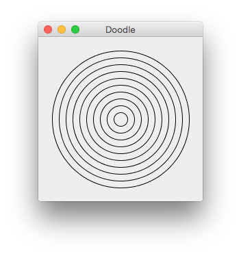

Many outlined circles

```scala
manyShapes(10, outlinedCircle).draw
```

The rest of the exercise is just a matter of copying, renaming, and customising this function to produce the desired combinations of colours and shapes:

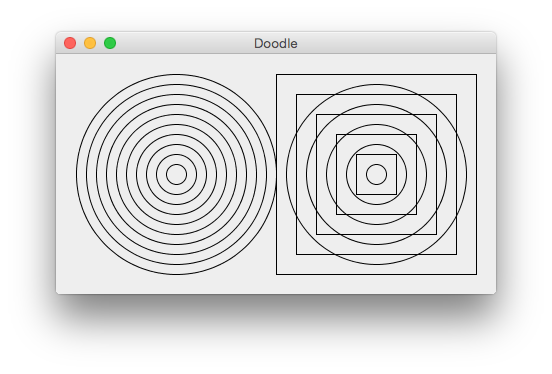

Many outlined circles beside many circles and squares

```scala
def circleOrSquare(n: Int) =
  if(n % 2 == 0) Rectangle(n*20, n*20) else Circle(n*10)

(manyShapes(10, outlinedCircle) beside manyShapes(10, circleOrSquare)).draw
```

For extra credit, when you’ve written your code to create the sample shapes above, refactor it so you have two sets of base functions—one to produce colours and one to produce shapes. Combine these functions using a *combinator* as follows, and use the result of the combinator as an argument to `manyShapes`

```scala
  def colored(shape: Int => Image, color: Int => Color): Int => Image =
    (n: Int) => ???
```

The simplest solution is to define three `singleShapes` as follows:

```scala
def manyShapes(n: Int, singleShape: Int => Image): Image =
  if(n == 1) {
    singleShape(n)
  } else {
    singleShape(n) on manyShapes(n - 1, singleShape)
  }

def rainbowCircle(n: Int) = {
  val color = Color.blue desaturate 0.5.normalized spin (n * 30).degrees
  val shape = Circle(50 + n*12)
  shape lineWidth 10 lineColor color
}

def fadingTriangle(n: Int) = {
  val color = Color.blue fadeOut (1 - n / 20.0).normalized
  val shape = Triangle(100 + n*24, 100 + n*24)
  shape lineWidth 10 lineColor color
}

def rainbowSquare(n: Int) = {
  val color = Color.blue desaturate 0.5.normalized spin (n * 30).degrees
  val shape = Rectangle(100 + n*24, 100 + n*24)
  shape lineWidth 10 lineColor color
}

val answer =
  manyShapes(10, rainbowCircle) beside
  manyShapes(10, fadingTriangle) beside
  manyShapes(10, rainbowSquare)
```

```scala
def manyShapes(n: Int, singleShape: Int => Image): Image =
  if(n == 1) {
    singleShape(n)
  } else {
    singleShape(n) on manyShapes(n - 1, singleShape)
  }

def colored(shape: Int => Image, color: Int => Color): Int => Image =
  (n: Int) =>
    shape(n) lineWidth 10 lineColor color(n)

def fading(n: Int): Color =
  Color.blue fadeOut (1 - n / 20.0).normalized

def spinning(n: Int): Color =
  Color.blue desaturate 0.5.normalized spin (n * 30).degrees

def size(n: Int): Double =
  50 + 12 * n

def circle(n: Int): Image =
  Circle(size(n))

def square(n: Int): Image =
  Rectangle(2*size(n), 2*size(n))

def triangle(n: Int): Image =
  Triangle(2*size(n), 2*size(n))

val answer =
  manyShapes(10, colored(circle, spinning)) beside
  manyShapes(10, colored(triangle, fading)) beside
  manyShapes(10, colored(square, spinning))
```

## 3.4 Take Home Points

Scala is both functional and object oriented. In this chapter we were introduced to some of its functional aspects.

The most important aspect of a functional language is that *functions are first class values*. This allows us to parameterize one method or function by another, which is an enormously powerful abstraction tool that we saw in action with our revisions to the `manyShapes` method:

```scala
def manyShapes(n: Int, singleShape: Int => Image): Image =
  ???
```

So far we have mainly written code using recursion. However, don’t be fooled into think that Scala is all about recursion. In the next chapter we will look at Scala’s collections library, which provides many convenient high level transformation methods that take functions as parameters.

# 4 Collections

An introduction to functional programming wouldn’t be complete without discussing transformations on collections. In this chapter we will look at the `Lists`, which are without a doubt the best known data type in functional programming.

## 4.1 Creating Sequences

The standard library in Scala contains many types of sequence: mutable and immutable, lazy and eager, parallel and sequential. In this course we will use two types of sequence: `Lists` and `Ranges`. Both are simple, immutable, eager data types. Let’s see them in action.

We can create a list in Scala by calling the `List` factory method as follows:

```scala
List(1, 2, 3, 4, 5)
// res0: List[Int] = List(1, 2, 3, 4, 5)
```

The result of the expression is of type `List[Int]`, which we read as “list of integers”. If we call the factory method with `String` arguments, the type of the result changes accordingly:

```scala
List("a", "b", "c", "d", "e")
// res1: List[String] = List(a, b, c, d, e)
```

`Lists` are useful for storing short sequences of values. If we want to create long sequences of numbers, however, we are better off using `Ranges`. We can create these using the `until` method of `Int` or `Double`:

```scala
0 until 10
// res0: scala.collection.immutable.Range.Inclusive =
//   Range(0, 1, 2, 3, 4, 5, 6, 7, 8, 9)

0.0 until 5.0
// res1: scala.collection.immutable.Range.Inclusive =
//   Range(0.0, 1.0, 2.0, 3.0, 4.0)
```

`Ranges` have a `by` method that allows us to change the step between consecutive elements of the range:

```scala
0 until 10 by 2
// res1: scala.collection.immutable.Range.Inclusive =
//   Range(0, 2, 4, 6, 8)

0.0 until 1.0 by 0.3
// res2: scala.collection.immutable.Range.Inclusive =
//   Range(0.0, 0.3, 0.6, 0.9)
```

Many methods in Doodle are designed to work with `Lists` and `Ranges`, but you can use the `toList` of any `Range` to convert it to a `List` if you run into problems:

```scala
(0 until 10).toList
// res0: List[Int] =
//   List(0, 1, 2, 3, 4, 5, 6, 7, 8, 9)
```

Let’s see what we can do with these sequences.